# W10：假設檢定與決策——法庭上的攻防

心理教育統計 2026

授課教師：陳紹慶 | e-mail: csc2009@mail.tcu.edu.tw

2026/05/04

# 本週學習目標

**理解概念**：

1. 區分虛無假設 ($H_0$) 與對立假設 ($H_1$)
2. 理解 **p 值**的意義與決策邏輯
3. 掌握 **t 統計量**的「訊號/雜訊」直覺
4. 認識 **Cohen’s d** 效果量

**數學工具**：

1. $t = \frac{\bar{X} - \mu_0}{SE}$
2. Cohen’s $d = \frac{\bar{X} - \mu_0}{s}$

**軟體操作**：

1. 在 jamovi 中執行 One Sample T-Test
2. 設定 Test Value、勾選 Effect Size

## 對應教材

- 《用 jamovi 上手統計學》
  - [第 9 章：假設檢定](https://scgeeker.github.io/lsj-book-zh_tw/09-Hypothesis-testing.html)
  - [第 11 章 11.1-11.2：單一樣本 t 檢定](https://scgeeker.github.io/lsj-book-zh_tw/11-Comparing-two-means.html#sec-The-one-sample-t%E6%AA%A2%E5%AE%9A)

**簡報示範資料**：Zeppo（20 位心理學學生成績） - `lsj data`

**作業資料**：個人化 `W10_Hypothesis_Test_[學號].csv`

# Part 1：法庭譬喻——無罪推定🧠

## 假設檢定 = 法庭審判

**法庭**

- 被告**推定無罪**
- 檢察官提出**證據**
- 證據夠強 → **判有罪**
- 證據不足 → **維持無罪**

**統計**

- $H_0$：效果**不存在**
- 數據 = **證據**
- $p < .05$ → **拒絕 $H_0$**
- $p \geq .05$ → **保留 $H_0$**

> 法庭不會「證明無罪」，統計也不會「證明 $H_0$ 為真」——只是**證據不足以推翻**。

## 兩種假設

**虛無假設 $H_0$（被告）**：

- 「沒有效果」、「沒有差異」、「跟母群一樣」
- 例：心理系學生的統計成績 = 全校平均 67.5

**對立假設 $H_1$（檢方主張）**：

- 「有效果」、「有差異」
- 例：心理系學生的成績 ≠ 67.5

> $H_0$ 是預設立場，$H_1$ 是你想證明的事。

## 四種判決結果

|  | 判「有罪」（拒絕 $H_0$） | 判「無罪」（保留 $H_0$） |
| --- | --- | --- |
| **真的有罪**（$H_0$ 為假） | ✓ 正確拒絕 | ✗ **Type II 錯誤** ($\beta$) |
| **真的無罪**（$H_0$ 為真） | ✗ **Type I 錯誤** ($\alpha$) | ✓ 正確保留 |

- **Type I 錯誤**（$\alpha$）：冤枉好人（誤判有效）
- **Type II 錯誤**（$\beta$）：放過壞人（漏掉真正的效果）

> 我們設定 $\alpha = .05$，最多容忍 5% 的冤罪率。

## p 值 = 證據強度

**p 值的定義**：

> 假設 $H_0$ 為真，觀察到**如此極端**的資料之機率

**決策規則**：

- $p < \alpha$（通常是 .05） → 證據太罕見 → **拒絕 $H_0$**
- $p \geq \alpha$ → 證據不夠罕見 → **保留 $H_0$**

**注意**：p 值**不是** $H_0$ 為真的機率！

# Part 2：t 統計量——訊號與雜訊🧠👨‍💻

## Zeppo 的課題

**情境**：20 位心理系學生的統計成績

全校學生統計平均成績 = **67.5**（$\mu_0$）

心理系樣本平均成績 = **72.3**（$\bar{X}$），樣本標準差 = **9.52**（$s$）

**問題**：心理系比全校高 4.8 分，是真的比較厲害，還是只是運氣好？

## Zeppo 的成績分佈

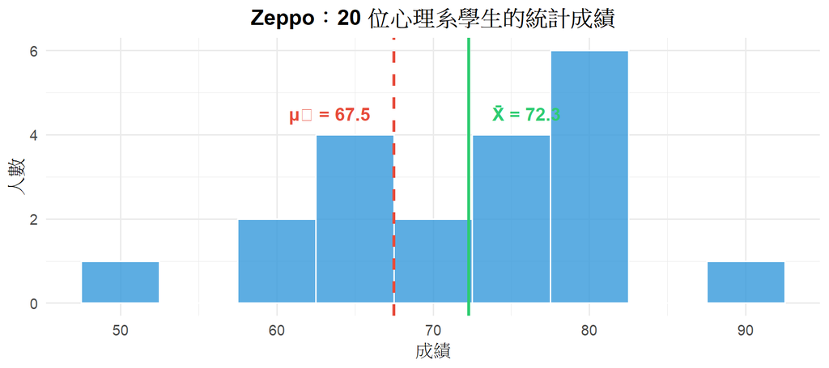

> 紅線 = 全校常模，綠線 = 心理系平均。差距**顯著**嗎？

## t 統計量的直覺

$$t = \frac{\text{訊號}}{\text{雜訊}} =
\frac{\bar{X} - \mu_0}{SE}$$

- **分子（訊號）**：樣本跟常模**差多少**
- **分母（雜訊）**：這個差距有多少是**取樣誤差**

## Zeppo 的 t 值計算

$$SE = \frac{s}{\sqrt{N}} =
\frac{9.52}{\sqrt{20}} = 2.13$$

$$t = \frac{72.3 - 67.5}{2.13} =
\frac{4.8}{2.13} = 2.25$$

**解讀**：樣本與常模的差距是**標準誤的 2.25 倍**

> $|t|$ 越大 → 訊號相對於雜訊越強 → 越不可能只是運氣。

## 連結 W9 的 t 分佈

回想 W9 學過的：

- **t 分佈**的形狀由 $df = N - 1$ 決定
- $df$ 越小 → 尾巴越厚 → 要更極端才算「罕見」

Zeppo 的 $df = 20 - 1 = 19$

現在的問題：$t = 2.25$ 在 $df = 19$ 的 t 分佈上，算罕見嗎？

# Part 3：p 值決策樹🧠👨‍💻

## t 分佈上的 Zeppo

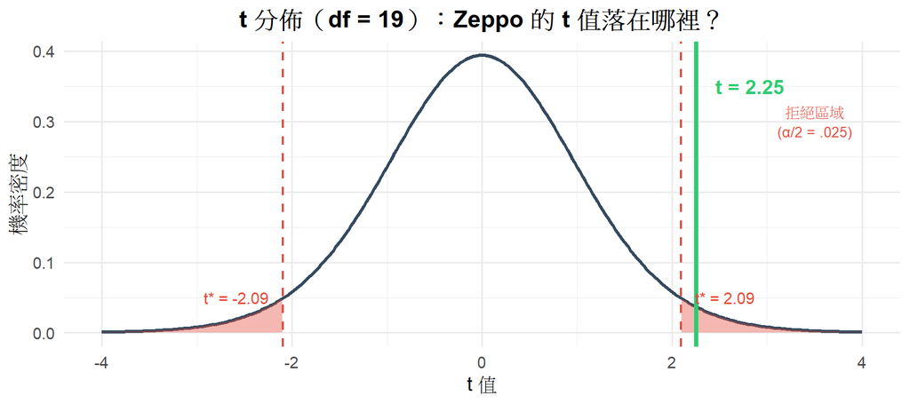

> 綠線（觀察 t）超過了紅虛線（臨界值）→ 落入拒絕區域！

## 雙尾 vs 單尾

**雙尾檢定**（$H_1: \mu \neq \mu_0$）

- 「有差異」（不管方向）
- 兩邊尾巴各 $\alpha/2 = .025$
- 通常是預設選擇

**單尾檢定**（$H_1: \mu > \mu_0$）

- 「比較好」（指定方向）
- 只看一邊尾巴 $\alpha = .05$
- 需要事前理論支持

**Zeppo 的結果（雙尾）**：

$t(19) = 2.25,\quad p = 0.036 < .05$

**拒絕 $H_0$**：心理系學生成績顯著高於全校平均

## jamovi 操作：One Sample T-Test

**步驟**：

1. **T-Tests → One Sample T-Test**
2. 將變項拖入 **Dependent Variables**
3. 設定 **Test Value** = 母群常模（如 67.5）
4. 勾選 **Effect Size**（Cohen’s d）

## jamovi 操作（續）

**Hypothesis 選項**：

| 選項 | 意義 | 何時使用 |
| --- | --- | --- |
| $\neq$ Test Value | 雙側（預設） | 只要知道「有沒有差」 |
| $>$ Test Value | 右側 | 預期**高於** $\mu$ |
| $<$ Test Value | 左側 | 預期**低於** $\mu$ |

**讀取報表**：

- **t**：t 統計量
- **df**：自由度（$N - 1$）
- **p**：p 值（決定是否顯著）
- **Cohen’s d**：效果量

# Part 4：效果量——真正的重要性指標🧠

- 法官的量刑指標

## Cohen’s d 的直覺

$$d = \frac{\bar{X} - \mu_0}{s} =
\frac{72.3 - 67.5}{9.52} = 0.5$$

**意義**：差距相當於「幾個樣本標準差」

| Cohen’s d | 效果大小 | 日常譬喻 |
| --- | --- | --- |
| 0.2 | 小 | 看不太出來 |
| 0.5 | 中 | 仔細看會注意到 |
| 0.8 | 大 | 一眼就看到 |

> Zeppo 的 $d = 0.5$（中等效果）

## 兩個分佈的重疊

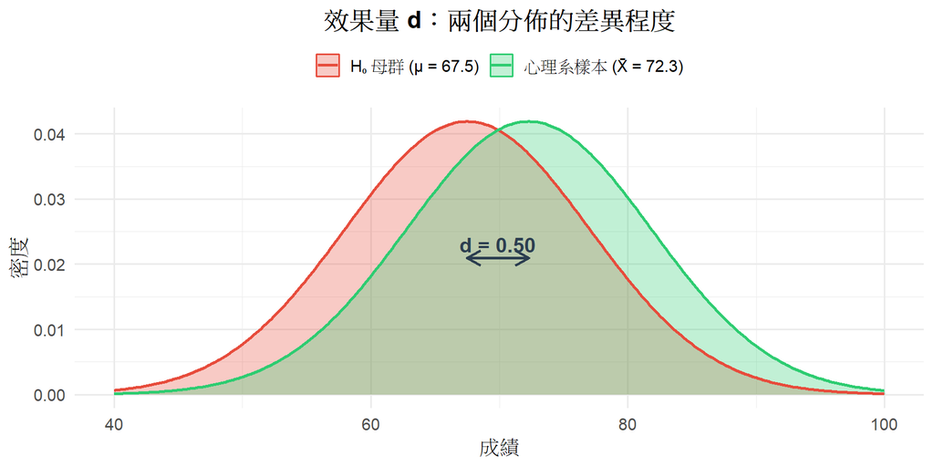

## 顯著 ≠ 重要：N 的陷阱

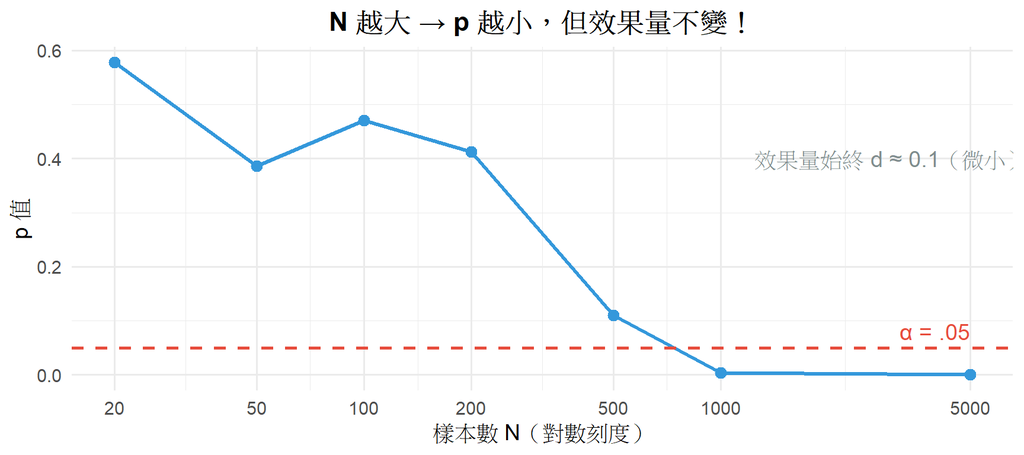

> 同樣微小的差異（$d \approx 0.1$），$N = 5000$ 時 $p$ 就能 $< .05$。

## 為什麼需要效果量？

**p 值的限制**：

- 來自**取樣分佈**
- 同時受**效果大小**和**樣本數**影響
- $N$ 夠大，能增幅微小差異($SE$)
- 不代表「這個效果**有多大**」

**d 的優勢**：

- 來自**樣本分佈**
- 反映效果的**實質大小**
- 不受 $N$ 影響($s$)
- 可以比較跨研究結果

> **p 值告訴你「有沒有」，d 告訴你「有多少」**

# Part 5：作業說明

## 本週作業：顯著性陷阱

**資料**：個人化 `W10_Hypothesis_Test_[學號].csv`

你的資料包含 2 個變項(`Total_Score`)：

| 變項 | N | 說明 |
| --- | --- | --- |
| `Small_Study` | 20 | 大偏移，小樣本 |
| `Huge_Study` | 500 | 小偏移，大樣本 |

**Test Value**（母群平均數）：見你的個人資料說明

## 任務 1：執行檢定

**操作**：

1. 匯入 CSV，設定 Small_Study 和 Huge_Study 為 **Continuous**
2. 注意 Small_Study 只有 20 筆有效資料（其餘為 NA）
3. **T-Tests → One Sample T-Test**
4. **Test Value** 設為你的母群平均數
5. 勾選 **Effect Size**（Cohen’s d）

**記錄**：整理兩組的檢定結果

|  | Small_Study | Huge_Study |
| --- | --- | --- |
| N | 20 | 500 |
| Mean |  |  |
| t |  |  |
| df |  |  |
| p |  |  |
| Cohen’s d |  |  |
| 結論 | 顯著？ | 顯著？ |

## 任務 2：決策對比

**問題**：比較兩組的 p 值和 Cohen’s d

- 哪一組 **p 值更小**（更顯著）？
- 哪一組 **Cohen’s d 更大**（效果更大）？
- 為什麼差距小的 Huge_Study 反而「更顯著」？

**提示**：想想 $t = \frac{\bar{X} - \mu_0}{SE}$，SE 和 N 的關係

## 任務 3：觀念辨析

在報告中回答以下問題：

1. **Q1: 樣本數對 p 值的影響**：為什麼增加 N 會讓 p 值變小？請用 $SE = SD / \sqrt{N}$ 解釋。
2. **Q2: 效果量與實務重要性**：根據 Cohen’s d，哪個研究的發現比較有「實務重要性」？為什麼 d 比 p 更適合衡量效果大小？
3. **Q3: APA 格式報告**：針對 Small_Study 撰寫 APA 格式結果。 格式：$t(df) = \dots,\ p = \dots,\ d = \dots$

## 繳交要求

**檔案 1：學號_姓名_W10_Lab.omv**

- 兩個變項的 One Sample T-Test
- 勾選 Effect Size（Cohen’s d）

**檔案 2：學號_姓名_W10_Report.docx**

- 分析結果表格（兩組 t 檢定結果）
- 決策對比分析（任務 2）
- 反思問題：回答 3 題觀念問題

**繳交期限**：本週上課結束前

# 小結與展望

## 本週核心概念

1. **假設檢定 = 法庭**：$H_0$ 無罪推定 → 用數據（證據）決定是否推翻
2. **t 統計量**：訊號/雜訊比值，$t = (\bar{X} - \mu_0) / SE$
3. **p 值**：假設 $H_0$ 為真時，觀察到這麼極端數據的機率
4. **決策規則**：$p < .05$ → 拒絕 $H_0$
5. **效果量**：$d = (\bar{X} - \mu_0) / s$，不受 N 影響，衡量實質大小
6. **顯著 ≠ 重要**：大 N 能讓微小差異顯著，但 d 不會騙你

## W12 預告：兩組人怎麼比？

**下週問題**：

- 「實驗組 vs 控制組」該用什麼方法？
- 「前測 vs 後測」又該用什麼方法？
- 什麼是 Welch’s t？什麼時候需要它？

**核心概念**：

- 獨立樣本 t 檢定（蘋果 vs 橘子）
- 相依樣本 t 檢定（昨天的你 vs 今天的你）

**資料**：W12 個人化雙組實驗資料

## 課後資源

**電子書**：

- [第 9 章：假設檢定](https://scgeeker.github.io/lsj-book-zh_tw/09-Hypothesis-testing.html)
- [第 11 章 11.1-11.2：單一樣本 t 檢定](https://scgeeker.github.io/lsj-book-zh_tw/11-Comparing-two-means.html#sec-The-one-sample-t%E6%AA%A2%E5%AE%9A)

**關鍵術語對照**：

| 中文 | 英文 | 符號 |
| --- | --- | --- |
| 虛無假設 | Null Hypothesis | $H_0$ |
| 對立假設 | Alternative Hypothesis | $H_1$ |
| p 值 | p-value | $p$ |
| 顯著水準 | Significance Level | $\alpha$ |
| 效果量 | Effect Size | $d$ |
| 型一錯誤 | Type I Error | $\alpha$ |
| 型二錯誤 | Type II Error | $\beta$ |